# ISLR-R: 5. Decision Tree

2023-05-02

In this lab you will work through Section 8.3. The rpart() R function is also included as an alternative to tree().

Load Dataset:

```r
import::from(MASS, Boston)
import::from(ISLR, Carseats)
```

## Fitting Classification Trees

Turn into a classification problem (two class: High and Low)

```r
High <- Carseats %$% as.factor(ifelse(Sales <= 8, "No", "Yes"))
Carseats1 <- data.frame(Carseats, High)
Carseats1 %>% head()
```

```
##   Sales CompPrice Income Advertising Population Price ShelveLoc Age Education
## 1  9.50       138     73          11        276   120       Bad  42        17
## 2 11.22       111     48          16        260    83      Good  65        10
## 3 10.06       113     35          10        269    80    Medium  59        12
## 4  7.40       117    100           4        466    97    Medium  55        14
## 5  4.15       141     64           3        340   128       Bad  38        13
## 6 10.81       124    113          13        501    72       Bad  78        16
##   Urban  US High
## 1   Yes Yes  Yes
## 2   Yes Yes  Yes
## 3   Yes Yes  Yes
## 4   Yes Yes   No
## 5   Yes  No   No
## 6    No Yes  Yes
```

Build a classification tree

```r
tree.carseats <- tree::tree(High ~ . - Sales, Carseats1)
summary(tree.carseats)
```

```
##
## Classification tree:
## tree::tree(formula = High ~ . - Sales, data = Carseats1)
## Variables actually used in tree construction:
## [1] "ShelveLoc"   "Price"       "Income"      "CompPrice"   "Population"
## [6] "Advertising" "Age"         "US"
## Number of terminal nodes:  27
## Residual mean deviance:  0.4575 = 170.7 / 373
## Misclassification error rate: 0.09 = 36 / 400
```

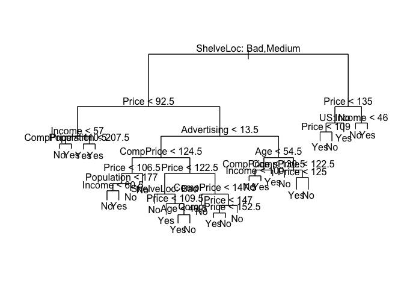

```r
plot(tree.carseats)
text(tree.carseats, pretty = 0)
```

```r
tree.carseats
```

```
## node), split, n, deviance, yval, (yprob)
##       * denotes terminal node
##
##   1) root 400 541.500 No ( 0.59000 0.41000 )
##     2) ShelveLoc: Bad,Medium 315 390.600 No ( 0.68889 0.31111 )
##       4) Price < 92.5 46  56.530 Yes ( 0.30435 0.69565 )
##         8) Income < 57 10  12.220 No ( 0.70000 0.30000 )
##          16) CompPrice < 110.5 5   0.000 No ( 1.00000 0.00000 ) *
##          17) CompPrice > 110.5 5   6.730 Yes ( 0.40000 0.60000 ) *
##         9) Income > 57 36  35.470 Yes ( 0.19444 0.80556 )
##          18) Population < 207.5 16  21.170 Yes ( 0.37500 0.62500 ) *
##          19) Population > 207.5 20   7.941 Yes ( 0.05000 0.95000 ) *
##       5) Price > 92.5 269 299.800 No ( 0.75465 0.24535 )
##        10) Advertising < 13.5 224 213.200 No ( 0.81696 0.18304 )
##          20) CompPrice < 124.5 96  44.890 No ( 0.93750 0.06250 )
##            40) Price < 106.5 38  33.150 No ( 0.84211 0.15789 )
##              80) Population < 177 12  16.300 No ( 0.58333 0.41667 )
##               160) Income < 60.5 6   0.000 No ( 1.00000 0.00000 ) *
##               161) Income > 60.5 6   5.407 Yes ( 0.16667 0.83333 ) *
##              81) Population > 177 26   8.477 No ( 0.96154 0.03846 ) *
##            41) Price > 106.5 58   0.000 No ( 1.00000 0.00000 ) *
##          21) CompPrice > 124.5 128 150.200 No ( 0.72656 0.27344 )
##            42) Price < 122.5 51  70.680 Yes ( 0.49020 0.50980 )
##              84) ShelveLoc: Bad 11   6.702 No ( 0.90909 0.09091 ) *
##              85) ShelveLoc: Medium 40  52.930 Yes ( 0.37500 0.62500 )
##               170) Price < 109.5 16   7.481 Yes ( 0.06250 0.93750 ) *
##               171) Price > 109.5 24  32.600 No ( 0.58333 0.41667 )
##                 342) Age < 49.5 13  16.050 Yes ( 0.30769 0.69231 ) *
##                 343) Age > 49.5 11   6.702 No ( 0.90909 0.09091 ) *
##            43) Price > 122.5 77  55.540 No ( 0.88312 0.11688 )
##              86) CompPrice < 147.5 58  17.400 No ( 0.96552 0.03448 ) *
##              87) CompPrice > 147.5 19  25.010 No ( 0.63158 0.36842 )
##               174) Price < 147 12  16.300 Yes ( 0.41667 0.58333 )
##                 348) CompPrice < 152.5 7   5.742 Yes ( 0.14286 0.85714 ) *
##                 349) CompPrice > 152.5 5   5.004 No ( 0.80000 0.20000 ) *
##               175) Price > 147 7   0.000 No ( 1.00000 0.00000 ) *
##        11) Advertising > 13.5 45  61.830 Yes ( 0.44444 0.55556 )
##          22) Age < 54.5 25  25.020 Yes ( 0.20000 0.80000 )
##            44) CompPrice < 130.5 14  18.250 Yes ( 0.35714 0.64286 )
##              88) Income < 100 9  12.370 No ( 0.55556 0.44444 ) *
##              89) Income > 100 5   0.000 Yes ( 0.00000 1.00000 ) *
##            45) CompPrice > 130.5 11   0.000 Yes ( 0.00000 1.00000 ) *
##          23) Age > 54.5 20  22.490 No ( 0.75000 0.25000 )
##            46) CompPrice < 122.5 10   0.000 No ( 1.00000 0.00000 ) *
##            47) CompPrice > 122.5 10  13.860 No ( 0.50000 0.50000 )
##              94) Price < 125 5   0.000 Yes ( 0.00000 1.00000 ) *
##              95) Price > 125 5   0.000 No ( 1.00000 0.00000 ) *
##     3) ShelveLoc: Good 85  90.330 Yes ( 0.22353 0.77647 )
##       6) Price < 135 68  49.260 Yes ( 0.11765 0.88235 )
##        12) US: No 17  22.070 Yes ( 0.35294 0.64706 )
##          24) Price < 109 8   0.000 Yes ( 0.00000 1.00000 ) *
##          25) Price > 109 9  11.460 No ( 0.66667 0.33333 ) *
##        13) US: Yes 51  16.880 Yes ( 0.03922 0.96078 ) *
##       7) Price > 135 17  22.070 No ( 0.64706 0.35294 )
##        14) Income < 46 6   0.000 No ( 1.00000 0.00000 ) *
##        15) Income > 46 11  15.160 Yes ( 0.45455 0.54545 ) *
```

Estimate the accuracy of the tree

```r
set.seed(1)
train <- sample(1:nrow(Carseats1), 200)
Carseats.test <- Carseats1[-train, ]
High.test <- High[-train]
tree.carseats <- tree::tree(High ~ . - Sales, Carseats1, subset = train)
tree.pred <- predict(tree.carseats, Carseats.test, type = "class")
confusion.matrix <- table(tree.pred, High.test)
confusion.matrix
```

```
##          High.test
## tree.pred No Yes
##       No  84  37
##       Yes 35  44
```

```r
# There are some options for how accuracy is calculated
# 1. From the confusion table, sum the True Positive and True Negative classifications, then divide by the total number of observations.
accuracy.TNplusTP <- (84 + 44) / 200
cat(
  "Accuracy calculated from TP and TN metrics:",
  accuracy.TNplusTP, "\n"
)
```

```
## Accuracy calculated from TP and TN metrics: 0.64
```

```r
# 2. Calculate from the diagonal of the confusion matrix. This is equivalent to option 1, but uses the matrix rather than the hard-coded result.
accuracy.fromCM <- sum(diag(confusion.matrix)) / sum(confusion.matrix)
cat(
  "Accuracy calculated from diagonal of Confusion Matrix:",
  accuracy.fromCM, "\n"
)
```

```
## Accuracy calculated from diagonal of Confusion Matrix: 0.64
```

```r
# 3. Calculate directly from the test observations and predictions
accuracy.fromTestResults <- round(mean(tree.pred == High.test), 2)
cat("Accuracy from test results:", accuracy.fromTestResults, "\n")
```

```
## Accuracy from test results: 0.64
```

Use cross validation to choose tree complexity

```r
set.seed(3)
cv.carseats <- tree::cv.tree(tree.carseats, FUN = prune.misclass)
cv.carseats
```

```
## $size
## [1] 20 18 10  8  6  4  2  1
##
## $dev
## [1] 53 53 52 52 54 49 72 83
##
## $k
## [1] -Inf  0.0  0.5  1.5  2.0  4.0 12.0 19.0
##
## $method
## [1] "misclass"
##
## attr(,"class")
## [1] "prune"         "tree.sequence"
```

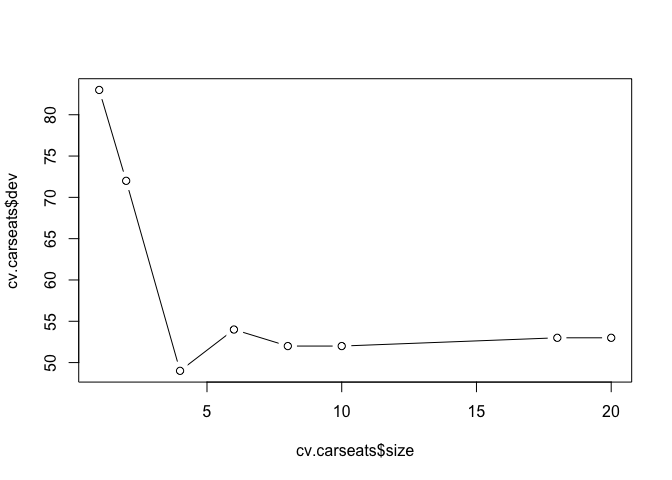

```r
plot(cv.carseats$size, cv.carseats$dev, type = "b")
```

Prune the tree with 6 terminal nodes

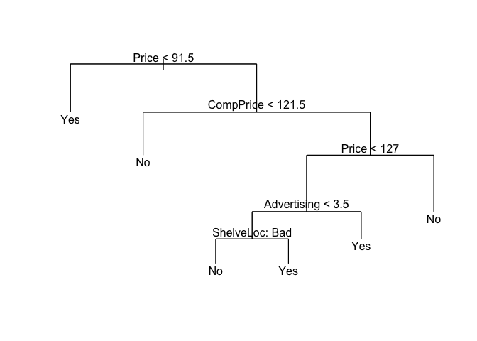

```r
prune.carseats <- tree::prune.tree(tree.carseats,
  best = 6,
  method = "misclass"
)
plot(prune.carseats)
text(prune.carseats, pretty = 0)
```

```r
tree.pred <- predict(prune.carseats, Carseats.test, type = "class")
table(tree.pred, High.test)
```

```
##          High.test
## tree.pred No Yes
##       No  86  32
##       Yes 33  49
```

```r
(86 + 49) / 200
```

```
## [1] 0.675
```

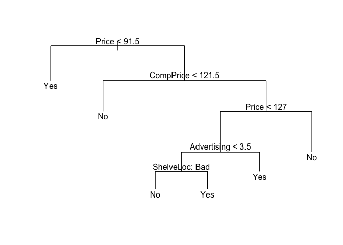

```r
prune.carseats <- tree::prune.tree(tree.carseats,
  best = 5,
  method = "misclass"
)
plot(prune.carseats)
text(prune.carseats, pretty = 0)
```

```r
tree.pred <- predict(prune.carseats, Carseats.test, type = "class")
table(tree.pred, High.test)
```

```
##          High.test
## tree.pred No Yes
##       No  86  32
##       Yes 33  49
```

```r
test.accuracy <- (86 + 49) / 200
test.accuracy
```

```
## [1] 0.675
```

```r
summary(prune.carseats)
```

```
##
## Classification tree:
## snip.tree(tree = tree.carseats, nodes = c(2L, 6L, 29L, 57L, 15L
## ))
## Variables actually used in tree construction:
## [1] "Price"       "CompPrice"   "Advertising" "ShelveLoc"
## Number of terminal nodes:  6
## Residual mean deviance:  0.8562 = 166.1 / 194
## Misclassification error rate: 0.16 = 32 / 200
```

```r
# It is unclear where the misclassification error rate given in the summary is
# derived from.
# The documentation suggests this is a training error.
# The TEST error can be calculated in 2 ways:
# 1. Sum of the False Postive + False Negative, divided by the total number of
#    observations
test.misclass.error <- (32 + 33) / 200
cat(
  "\nMisclassifications calculated from False Positive and False Negative Metrics:",
  test.misclass.error, "\n"
)
```

```
##
## Misclassifications calculated from False Positive and False Negative Metrics: 0.325
```

```r
# 2. 1-accuracy
test.misclass.fromAccuracy <- 1 - test.accuracy
cat(
  "Misclassifications calculated as 1-accuracy:",
  test.misclass.fromAccuracy, "\n"
)
```

```
## Misclassifications calculated as 1-accuracy: 0.325
```

Using CART to solve this problem

```r
fit <- rpart::rpart(High ~ . - Sales,
  method = "class", data = Carseats1[train, ]
)
# control <- rpart::rpart.control(minsplit = 2, cp = 0)
summary(fit)
```

```
## Call:
## rpart::rpart(formula = High ~ . - Sales, data = Carseats1[train,
##     ], method = "class")
##   n= 200
##
##           CP nsplit rel error    xerror       xstd
## 1 0.22891566      0 1.0000000 1.0000000 0.08395352
## 2 0.14457831      1 0.7710843 0.9397590 0.08310633
## 3 0.07228916      3 0.4819277 0.8192771 0.08071390
## 4 0.02409639      4 0.4096386 0.7228916 0.07808121
## 5 0.01000000      5 0.3855422 0.6506024 0.07564500
##
## Variable importance
##       Price   CompPrice   ShelveLoc         Age Advertising   Education
##          45          24          10           9           4           4
##       Urban      Income
##           3           1
##
## Node number 1: 200 observations,    complexity param=0.2289157
##   predicted class=No   expected loss=0.415  P(node) =1
##     class counts:   117    83
##    probabilities: 0.585 0.415
##   left son=2 (173 obs) right son=3 (27 obs)
##   Primary splits:
##       Price       < 91.5  to the right, improve=11.913680, (0 missing)
##       ShelveLoc   splits as  LRL,       improve=11.099750, (0 missing)
##       Age         < 54.5  to the right, improve= 5.522771, (0 missing)
##       Income      < 60.5  to the left,  improve= 5.280667, (0 missing)
##       Advertising < 6.5   to the left,  improve= 3.439267, (0 missing)
##   Surrogate splits:
##       CompPrice < 95.5  to the right, agree=0.88, adj=0.111, (0 split)
##
## Node number 2: 173 observations,    complexity param=0.1445783
##   predicted class=No   expected loss=0.3468208  P(node) =0.865
##     class counts:   113    60
##    probabilities: 0.653 0.347
##   left son=4 (55 obs) right son=5 (118 obs)
##   Primary splits:
##       CompPrice   < 121.5 to the left,  improve=9.114323, (0 missing)
##       ShelveLoc   splits as  LRL,       improve=8.343408, (0 missing)
```

[output cut: 67 more lines]

```
##
## Node number 21: 10 observations
##   predicted class=Yes  expected loss=0.4  P(node) =0.05
##     class counts:     4     6
##    probabilities: 0.400 0.600
##
## Node number 22: 12 observations
##   predicted class=No   expected loss=0.25  P(node) =0.06
##     class counts:     9     3
##    probabilities: 0.750 0.250
##
## Node number 23: 46 observations
##   predicted class=Yes  expected loss=0.173913  P(node) =0.23
##     class counts:     8    38
##    probabilities: 0.174 0.826
```

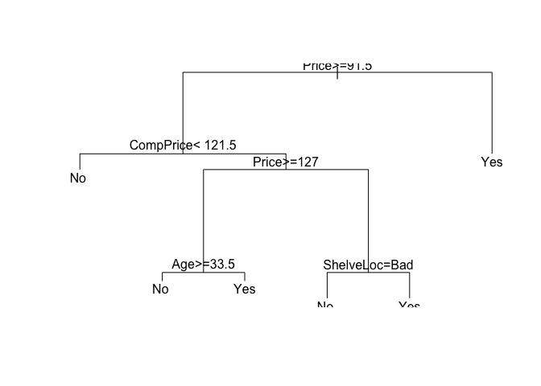

```r
plot(fit)
text(fit, pretty = 0)
```

## Fitting Regression Trees

```r
set.seed(1)
train <- sample(1:nrow(Boston), nrow(Boston) / 2)
```

Grow the regression tree

```r
tree.boston <- tree::tree(medv ~ ., Boston, subset = train)
summary(tree.boston)
```

```
##
## Regression tree:
## tree::tree(formula = medv ~ ., data = Boston, subset = train)
## Variables actually used in tree construction:
## [1] "rm"    "lstat" "crim"  "age"
## Number of terminal nodes:  7
## Residual mean deviance:  10.38 = 2555 / 246
## Distribution of residuals:
##     Min.  1st Qu.   Median     Mean  3rd Qu.     Max.
## -10.1800  -1.7770  -0.1775   0.0000   1.9230  16.5800
```

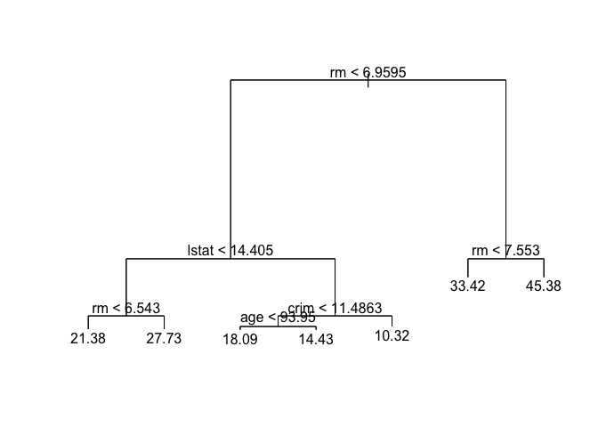

```r
plot(tree.boston)
text(tree.boston, pretty = 0)
```

Use cross validation to choose tree complexity

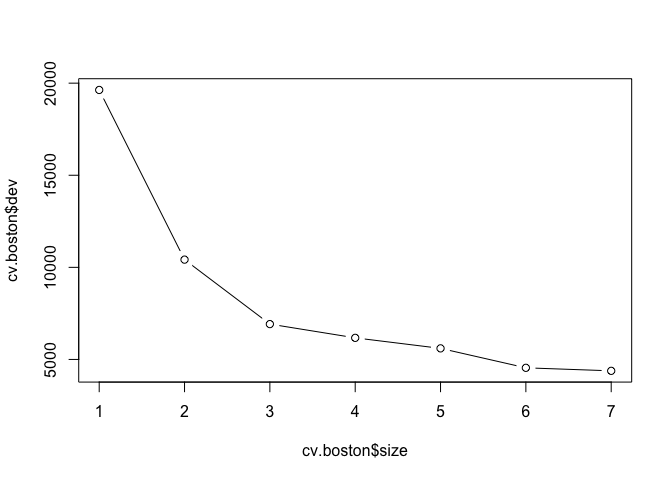

```r
cv.boston <- tree::cv.tree(tree.boston)
plot(cv.boston$size, cv.boston$dev, type = "b")
```

```r
cv.boston
```

```
## $size
## [1] 7 6 5 4 3 2 1
##
## $dev
## [1]  4380.849  4544.815  5601.055  6171.917  6919.608 10419.472 19630.870
##
## $k
## [1]       -Inf   203.9641   637.2707   796.1207  1106.4931  3424.7810 10724.5951
##
## $method
## [1] "deviance"
##
## attr(,"class")
## [1] "prune"         "tree.sequence"
```

Prune the tree

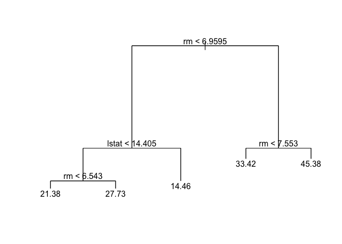

```r
prune.boston <- tree::prune.tree(tree.boston, best = 5)
plot(prune.boston)
text(prune.boston, pretty = 0)
```

Estimate the error of the tree

```r
yhat <- predict(tree.boston, newdata = Boston[-train, ])
boston.test <- Boston[-train, "medv"]
mean((yhat - boston.test)^2)
```

```
## [1] 35.28688
```

```r
yhat <- predict(prune.boston, newdata = Boston[-train, ])
boston.test <- Boston[-train, "medv"]
mean((yhat - boston.test)^2)
```

```
## [1] 35.90102
```

## Bagging

```r
set.seed(1)
train <- sample(1:nrow(Boston), nrow(Boston) / 2)
n_var <- dim(Boston)[2] - 1
n_var
```

```
## [1] 13
```

Generate bagged trees

```r
bag.boston <- randomForest::randomForest(medv ~ .,
  data = Boston, subset = train, mtry = n_var, ntree = 500, importance = TRUE
)
bag.boston
```

```
##
## Call:
##  randomForest(formula = medv ~ ., data = Boston, mtry = n_var,      ntree = 500, importance = TRUE, subset = train)
##                Type of random forest: regression
##                      Number of trees: 500
## No. of variables tried at each split: 13
##
##           Mean of squared residuals: 11.33119
##                     % Var explained: 85.26
```

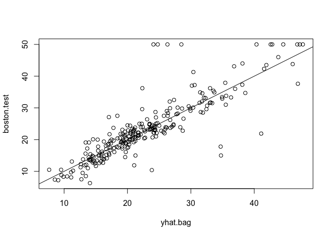

```r
yhat.bag <- predict(bag.boston, newdata = Boston[-train, ])
boston.test <- Boston[-train, "medv"]
plot(yhat.bag, boston.test)
abline(0, 1)
```

```r
mean((yhat.bag - boston.test)^2)
```

```
## [1] 23.4579
```

Try increasing the number of trees

```r
bag.boston <- randomForest::randomForest(medv ~ .,
  data = Boston, subset = train, mtry = n_var, ntree = 1000
)
yhat.bag <- predict(bag.boston, newdata = Boston[-train, ])
bag.boston
```

```
##
## Call:
##  randomForest(formula = medv ~ ., data = Boston, mtry = n_var,      ntree = 1000, subset = train)
##                Type of random forest: regression
##                      Number of trees: 1000
## No. of variables tried at each split: 13
##
##           Mean of squared residuals: 11.22646
##                     % Var explained: 85.4
```

```r
mean((yhat.bag - boston.test)^2)
```

```
## [1] 23.41157
```

## Random Forest

- Bootstrapping training data (same with bagging)
- Column sub-sampling
  - the essence of the RF
  - without it, bagging a good deal of homogeneous models may not reduce the variance

```r
set.seed(1)
rf.boston <- randomForest::randomForest(medv ~ .,
  data = Boston, subset = train, mtry = n_var / 3, ntree = 500,
  importance = TRUE
)
rf.boston
```

```
##
## Call:
##  randomForest(formula = medv ~ ., data = Boston, mtry = n_var/3,      ntree = 500, importance = TRUE, subset = train)
##                Type of random forest: regression
##                      Number of trees: 500
## No. of variables tried at each split: 4
##
##           Mean of squared residuals: 10.23441
##                     % Var explained: 86.69
```

```r
yhat.rf <- predict(rf.boston, newdata = Boston[-train, ])
mean((yhat.rf - boston.test)^2)
```

```
## [1] 18.11686
```

Feature importance:

- Gini impurity reduction: the Gini impurity is reduced each time a feature is used to split the data in a tree. The importance is estimated by averaging for each variable the reduction
- permutation importance: by randomly permute values of a variable, and the model performance will decrease if a variable is important. The performance is evaluated both **before** and **after** permuting the feature values (e.g. for the OOB samples), and the MSE difference is averaged to evaluate the importance.

```r
randomForest::importance(rf.boston)
```

```
##           %IncMSE IncNodePurity
## crim    15.372334    1220.14856
## zn       3.335435     194.85945
## indus    6.964559    1021.94751
## chas     2.059298      69.68099
## nox     14.009761    1005.14707
## rm      28.693900    6162.30720
## age     13.832143     708.55138
## dis     10.317731     852.33701
## rad      4.390624     162.22597
## tax      7.536563     564.60422
## ptratio  9.333716    1163.39624
## black    8.341316     355.62445
## lstat   27.132450    5549.25088
```

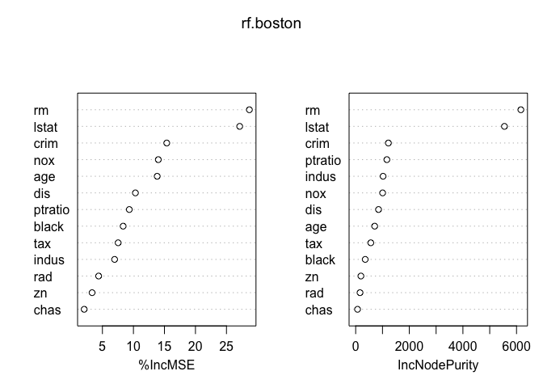

```r
randomForest::varImpPlot(rf.boston)
```

## Boosting

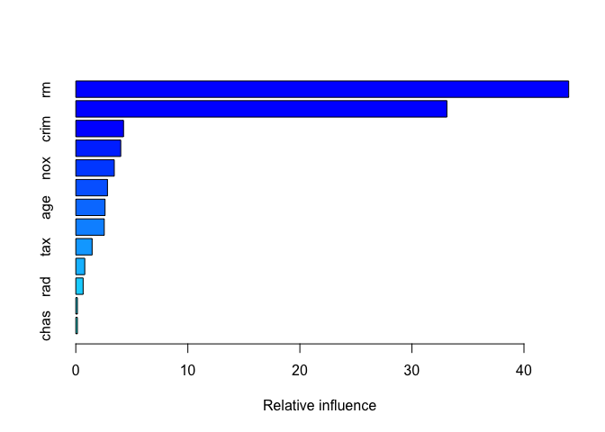

```
##             var    rel.inf
## rm           rm 43.9919329
## lstat     lstat 33.1216941
## crim       crim  4.2604167
## dis         dis  4.0111090
## nox         nox  3.4353017
## black     black  2.8267554
## age         age  2.6113938
## ptratio ptratio  2.5403035
## tax         tax  1.4565654
## indus     indus  0.8008740
## rad         rad  0.6546400
## zn           zn  0.1446149
## chas       chas  0.1443986
```

```r
set.seed(1)
boost.boston <- gbm::gbm(medv ~ .,
  data = Boston[train, ],
  distribution = "gaussian", n.trees = 5000, interaction.depth = 4
)
summary(boost.boston)
```

```r
yhat.boost <- predict(boost.boston,
  newdata = Boston[-train, ],
  n.trees = 5000
)
mean((yhat.boost - boston.test)^2)
```

```
## [1] 18.84709
```

change the shrinkage factor and tree depth

```r
B <- 10000
lambda <- 0.02
d <- 2
boost.boston <- gbm::gbm(medv ~ .,
  data = Boston[train, ],
  distribution = "gaussian",
  n.trees = B, interaction.depth = d, shrinkage = lambda
)
boost.boston
```

```
## gbm::gbm(formula = medv ~ ., distribution = "gaussian", data = Boston[train,
##     ], n.trees = B, interaction.depth = d, shrinkage = lambda)
## A gradient boosted model with gaussian loss function.
## 10000 iterations were performed.
## There were 13 predictors of which 13 had non-zero influence.
```

```r
yhat.boost <- predict(boost.boston,
  newdata = Boston[-train, ], n.trees = B
)
mean((yhat.boost - boston.test)^2)
```

```
## [1] 16.95649
```

### Grid Search

1. Create a grid: i.e. create a hyper-parameter space
2. Split dataset: either training-validation or CV
3. Train and evaluate models
4. Compare performance